# Week 12 Homework - TidyTuesday 2 Trying fable package to do forecasting

Author

Leah Barkai

Published

November 18, 2025

## Introduction

This document is for my homework for week 12. With the [WHO TB Burden Data: Incidence, Mortality, and Population](https://github.com/rfordatascience/tidytuesday/blob/main/data/2025/2025-11-11/readme.md#who-tb-burden-data-incidence-mortality-and-population) dataset from TidyTuesday, I learned how to use the fable package to do time-series forecasting/modeling.

## Load Libraries

These are the libraries I needed for this homework assignment.

```r
library(tidyverse)
library(tidytuesdayR) #Data
library(tsibble) # Core package for tidy time series
library(fable)   # Modeling and forecasting (includes model() and forecast())
library(fabletools) # Modeling tools (often loaded with fable)
library(scales) # For formatting large numbers on the axis
```

## Read in data

This data was from TidyTuesday [WHO TB Burden Data: Incidence, Mortality, and Population](https://github.com/rfordatascience/tidytuesday/blob/main/data/2025/2025-11-11/readme.md#who-tb-burden-data-incidence-mortality-and-population). This is global tuberculosis (TB) burden estimates from the World Health Organization, using data curated via [the getTBinR R package by Sam Abbott](https://samabbott.co.uk/getTBinR/).

```r
tuesdata <- tt_load(2025, week = 45)  # approximate week — check which week corresponds to Nov 11
who_tb_data <- tuesdata$who_tb_data
```

## Data Dictionary

This data dictionary is available on [TidyTuesday](https://github.com/rfordatascience/tidytuesday/blob/main/data/2025/2025-11-11/readme.md#data-dictionary) for the Who TB Burden Data.

## Look at the data

This was to get an idea of what was in the data.

```
Rows: 5,117
Columns: 18
$ country               <chr> "Afghanistan", "Afghanistan", "Afghanistan", "Af…
$ g_whoregion           <chr> "Eastern Mediterranean", "Eastern Mediterranean"…
$ iso_numeric           <dbl> 4, 4, 4, 4, 4, 4, 4, 4, 4, 4, 4, 4, 4, 4, 4, 4, …
$ iso2                  <chr> "AF", "AF", "AF", "AF", "AF", "AF", "AF", "AF", …
$ iso3                  <chr> "AFG", "AFG", "AFG", "AFG", "AFG", "AFG", "AFG",…
$ year                  <dbl> 2000, 2001, 2002, 2003, 2004, 2005, 2006, 2007, …
$ c_cdr                 <dbl> 19, 26, 34, 32, 41, 47, 53, 59, 56, 50, 52, 50, …
$ c_newinc_100k         <dbl> 35, 50, 65, 61, 78, 90, 100, 111, 107, 95, 99, 9…
$ cfr                   <dbl> 0.37, 0.35, 0.31, 0.32, 0.28, 0.26, 0.24, 0.21, …
$ e_inc_100k            <dbl> 190, 189, 189, 189, 189, 189, 189, 189, 189, 189…
$ e_inc_num             <dbl> 38000, 38000, 40000, 43000, 44000, 46000, 48000,…
$ e_mort_100k           <dbl> 68.00, 63.00, 57.00, 58.00, 52.00, 47.00, 43.00,…
$ e_mort_exc_tbhiv_100k <dbl> 68.00, 63.00, 57.00, 58.00, 51.00, 47.00, 43.00,…
$ e_mort_exc_tbhiv_num  <dbl> 14000, 13000, 12000, 13000, 12000, 11000, 11000,…
$ e_mort_num            <dbl> 14000, 13000, 12000, 13000, 12000, 12000, 11000,…
$ e_mort_tbhiv_100k     <dbl> 0.17, 0.30, 0.27, 0.29, 0.29, 0.31, 0.32, 0.33, …
$ e_mort_tbhiv_num      <dbl> 34, 61, 58, 66, 67, 75, 82, 85, 96, 110, 120, 14…
$ e_pop_num             <dbl> 20130323, 20284311, 21378110, 22733047, 23560660…
```

## Clean the Data

```r
# Focusing on the Philippines for the time series
target_country <- "Philippines"

clean_data <- who_tb_data %>%
  filter(country == target_country) %>%  # Filtering to chosen country
  select(year, e_inc_num, e_pop_num) %>% # Select year, metric, and population column
  mutate(rate_per_100k = (e_inc_num / e_pop_num) * 100000) %>% #Calculate the Incidence Rate per 100,000 people
  select(year, value = rate_per_100k) %>% #Select time series columns and rename
  mutate(value = replace_na(value, 0)) %>% # Dealing with any missing values

  # Convert to a tsibble which is a special data frame for time series
  as_tsibble(index = year)

# Show the tsibble structure
clean_data
```

```
# A tsibble: 24 x 2 [1Y]
    year value
   <dbl> <dbl>
 1  2000  590.
 2  2001  580.
 3  2002  569.
 4  2003  559.
 5  2004  549.
 6  2005  540.
 7  2006  530.
 8  2007  520.
 9  2008  524.
10  2009  528.
# ℹ 14 more rows
```

## Time-Series Modeling and Forecasting

```r
# Create the model using the clean_data (Incidence Rate per 100k)
tb_model <- clean_data %>%
  model(
    ETS_model = ETS(value)) # Use the Exponential Smoothing model (ETS) with value which is a time-series forecasting method which makes predictions by giving more weight to recent observations and less weight to older ones - it is exponetial bc it is gradually decreasing weight

# Forecast for 5 years ahead
forecast_horizon <- 5
tb_forecast <- tb_model %>%      #Fitted model to function
  forecast(h = forecast_horizon) #Calculating future values

# Display the forecast results
tb_forecast
```

```
# A fable: 5 x 4 [1Y]
# Key:     .model [1]
  .model  year        value
  <chr>  <dbl>       <dist>
1 ETS_m…  2024  N(643, 339)
2 ETS_m…  2025  N(643, 678)
3 ETS_m…  2026 N(643, 1017)
4 ETS_m…  2027 N(643, 1356)
5 ETS_m…  2028 N(643, 1696)
# ℹ 1 more variable: .mean <dbl>
```

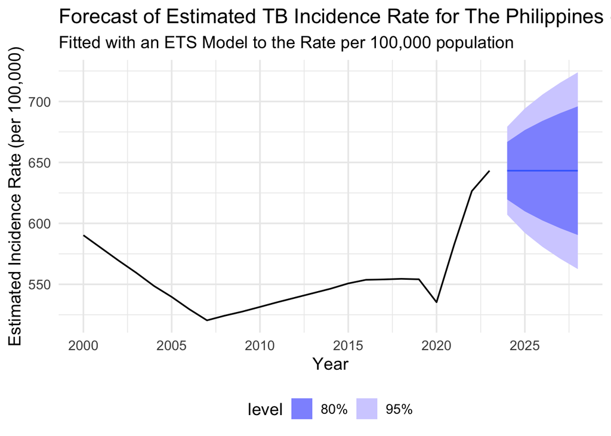

```r
# Combine historical data and forecast in single plot
tb_plot <- tb_forecast %>%
  autoplot(clean_data) + # autoplot is the specialized plotting function for forecast objects
  labs( #About the plot
    title = paste("Forecast of Estimated TB Incidence Rate for The Philippines (2022-2026)"),
    subtitle = "Fitted with an ETS Model to the Rate per 100,000 population",
    y = "Estimated Incidence Rate (per 100,000)",
    x = "Year"
  ) +
  # Format the Y-axis to display numbers nicely
  scale_y_continuous(labels = scales::number_format(accuracy = 1)) +
  theme_minimal(base_size = 14) +
  theme(legend.position = "bottom") +
  #X-axis
  scale_x_continuous(
    breaks = seq(from = 2000, to = 2026, by = 5), #Every 5 years
    labels = scales::label_number(accuracy = 1, big.mark = "")) #Whole numbers and remove thousands separator

#Printing it here
tb_plot
```

Summary of table:

The ETS model predicts that the TB Incidence (basically new cases) Rate (per 100,000) for the Philippines will stabilize near 645 by 2026, following a period of recent volatility, meaning the values have fluctuated in an unstable pattern. The purple shaded areas (prediction intervals) are very wide, demonstrating high uncertainty in the forecast due to the turbulent historical data. The 95% interval is particularly broad, indicating the true rate could be anywhere between approximately 560 and 730 per 100,000, underscoring the significant challenge in predicting the region’s future TB burden. I standardized the measure to cases per 100,000 people because different countries have different population sizes.